# DARL Project Status Notebook Template

COVIDMINDER

Durasia Anderson

October 09 2020

## Weekly Work Summary

- RCS ID: anderd11
- Project Name: COVIDMINDER
- Summary of work since last week
  - began process for cleaning up charts within State Determinants Visualizations for COVIDMINDER
  - reran State_Determinants_Visualization.Rmd to see which states have incorretly labeld features or include features that aren’t required to analyze social factors that impact COVID-19 patients
  - tired to add code (details below), but it doesn’t produce anything so I only have a screenshot attached until I can get it running

## Personal Contribution

- sorted through code to see which features need to be removed from charts: I reviewed the features that appear on the charts for each state’s MRR of Interested Variable graph; some are redundant, others are raw numbers but we need the rates to better evaluate the impact each feature may have
- used excel chart to note which features need to be updated or removed

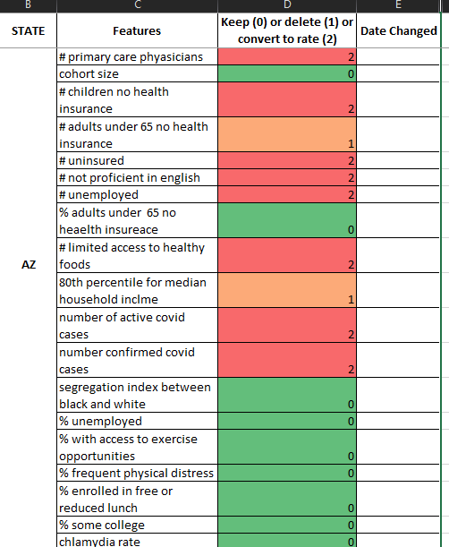

- attempted adding several lines of code to remove redundant attributes, but I need help determining why it isn’t working

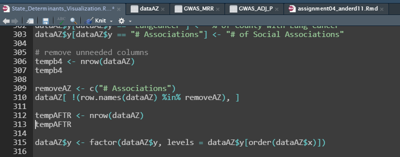

## Discussion of Primary Findings

- Discuss primary findings:
  - longitude and latitude are not exactly needed features, since we have the state names as indicator of location
  - many features repeat and show up in chart (i.e. # uninsured and % uninsured), which is redundant
  - Idaho image not loading for some reason
  - it works out nicely that for some states (like Arizona) only some of the # features show up as opposed to the rate - there is less to fix for these, but for states like Florida, a lot more needs to be redone